# Análisis demográfico de una especie explotada del amazonas: Carapa guianensis

Kenneth Barrantes

2023-11-26

# Introducción

La cuenca del Amazonas contiene más de la mitad de la selva tropical restante en el mundo, actualmente enfrentándose a cambios sin precedentes (Fearnside, 2005). Los seres humanos desempeñamos un papel protagonista en estos cambios en busca de nuestro propio beneficio (Wood, 2002). Sin embargo, esta explotación del recurso natural conlleva costos ambientales asociados (Peres et al., 2003), siendo necesaria una regulación con base teórica y conocimiento científico para graduar esta explotación de manera sostenible. Una alternativa de bajo costo y rápida producción de información son los censos demográficos a corto plazo (Chien et al., 2008).

Los patrones de abundancia, distribución y estructura demográfica brindan información para la toma de desiciones y explotación de recursos naturales (Bruna y Ribeiro, 2005). Sin embargo, deben evaluarse múltiples hábitats y factores que puedan influir sobre la demografía sobre la mayor parte de la distribución de la especie en cuetión. Carapa guianensis (Meliaceae) por la industria aceitera como por su recurso maderable (Dayanandan et al., 1999). Sin embargo, la explotación desregulada presenta un escenario hasta el momento desconocido para la especie, coincidiendo con un faltante de información de historia natural para la misma (Klimas, 2007).

Es por esto que en este reporte pretendo:

- Explorar estructuras demográficas de *Carapa guianensis* para dos diferentes ambientes (terra firme y baixo), enfocandome en adultos y subadultos en sitios con historia de explotación de frutos madera.
- Identificar factores que inciden sobre el patrón espacial en adultos y subadultos de *Carapa guianensis*

# Métodos y resultados

*Librerias*

```r
library(dplyr)
library(spatstat)
library(ggplot2)
library(car)
library(rcompanion)
library(FSA)
library(leaflet)
```

## Sitio de estudio

El estudio se realiza dentro de los límites de Brazilian Agricultural Research Corporation (Embrapa) (Fig. 1) al suroeste del estado de Acre, Brazil. En la zona predomina el bosque tropical húmedo (Holdridge, 1978), poseyendo una temporada lluviosa corta que se extiende junio a agosto con una humedad relativa que varía de 71 a 91% (UFAC, 2005). El sitio cuenta con una topografía mayormente plana, frecuentemente inundadas durante la estación lluviosa (Klimas et al., 2007).

```r
coord <- data.frame(site = "EMBRAPA", # nombre de sitio
                    lat = -10.025025, # coordenada decimal latitudinal
                    long = -67.706301, # coordenada decimal longitudinal
                    stringsAsFactors = TRUE) # convierte columna "site" a factor
```

```r
leaflet(coord) |> # carga dataset coord a paquete
    addTiles() |>
    setView(-67.706301, -10.025025, 5) |> # coordenadas centrales y zoom de proyección
    addAwesomeMarkers(~long, ~lat, popup = ~site) # añade marcadores por columna long y lat, etiquetas por site
```

[interactive chart not shown]

Fig 1. Sitio de estudio.

## Establecimiento parcelas y toma de datos:

Se establecen cuatro parcelas de 400 m x 400 m, con una distancia mínima de 500 m entre el punto más cercano de estas. Las parcelas son seleccionadas tomando como criterio que la mayor cobertura del paisaje se encuentre representada por bosuqe, para dos parcelas con zonas ocasionalmente inundadas (Baixo) y dos con baja frecuencia o ningún reporte de inundación (Terra firme). Dentro de cada parcela se identificó y asignó un código único a todos los individuos de *C. guianensis* que presentaran un diámetro a la altur del pecho (DAP, 130 cm) igual o mayor a 10 cm. De cada individuo seleccionado se midió el DAP, código único, parcela en que se encontró, estrato del dosel al que se encontraba su copa (codominante, dominante, intermediaria, suprimida), microambiente (radio de 2 m del tronco). A su vez se asignó la categoría de adultos a individuos con un DAP mayor a 20 cm y como subadultos a los que poseeyeran un diamétro inferior.

Tomado de Klimas et al. (2007).

## Análisis estadístico y resultados

Inicialmente exploré la base de datos para verificar errores de digitación, formato y disponibilidad de datos.

```r
# Cargar base de datos
carapa <- read.csv("../Datos/Mapeamento_parcelas_corregido.csv", # cargar base de datos
                   header = T, # asignar títulos según primera columna
                   sep = ";", # separador de columnas por ";"
                   stringsAsFactors = TRUE) # asignar columnas de caracteres como factores


carapa$Parc <- as.factor(carapa$Parc) # transformar "Parcelas" de entero a factor
carapa$Prod. <- as.logical(carapa$Prod.) # transformar "Producción de fruto" de entero a lógico

levels(carapa$copa) <- c("codominante", "dominante", "intermediaria", "suprimida")
```

```r
str(carapa) # estructura de la base de datos
```

```
## 'data.frame':    1298 obs. of  10 variables:
##  $ Parc    : Factor w/ 4 levels "1","2","3","4": 1 1 2 1 3 3 2 3 3 3 ...
##  $ Sub.P   : int  5 2 3 8 2 5 3 3 4 5 ...
##  $ NumAr   : Factor w/ 430 levels "1","10","100",..: 95 339 382 232 320 181 395 22 321 161 ...
##  $ x_rev   : int  200 50 100 350 50 200 100 100 150 200 ...
##  $ y       : int  40 56 64 97 100 119 132 155 160 194 ...
##  $ x       : int  -50 -50 -50 -50 -50 -50 -50 -50 -50 -50 ...
##  $ DAP     : num  32 13.2 18 21.7 10.3 31.9 36 13.4 33.7 47.3 ...
##  $ Prod.   : logi  TRUE FALSE FALSE FALSE FALSE TRUE ...
##  $ Ambiente: Factor w/ 3 levels "Baixio","Terra Firme",..: 1 3 2 2 1 1 2 1 1 1 ...
##  $ copa    : Factor w/ 4 levels "codominante",..: 1 3 3 3 4 1 1 4 2 2 ...
```

```r
DT::datatable(carapa, options = list(pageLength = 3)) # previsualización de datos
```

|  | Parc | Sub.P | NumAr | x_rev | y | x | DAP | Prod. | Ambiente | copa |
| --- | --- | --- | --- | --- | --- | --- | --- | --- | --- | --- |
| 1 | 1 | 5 | 183 | 200 | 40 | -50 | 32 | True | Baixio | codominante |
| 2 | 1 | 2 | 402 | 50 | 56 | -50 | 13.2 | False | Transicao | intermediaria |
| 3 | 2 | 3 | 56 | 100 | 64 | -50 | 18 | False | Terra Firme | intermediaria |
| 4 | 1 | 8 | 306 | 350 | 97 | -50 | 21.7 | False | Terra Firme | intermediaria |
| 5 | 3 | 2 | 386 | 50 | 100 | -50 | 10.3 | False | Baixio | suprimida |
| 6 | 3 | 5 | 260 | 200 | 119 | -50 | 31.9 | True | Baixio | codominante |
| 7 | 2 | 3 | 68 | 100 | 132 | -50 | 36 | True | Terra Firme | codominante |
| 8 | 3 | 3 | 117 | 100 | 155 | -50 | 13.4 | False | Baixio | suprimida |
| 9 | 3 | 4 | 387 | 150 | 160 | -50 | 33.7 | True | Baixio | dominante |
| 10 | 3 | 5 | 242 | 200 | 194 | -50 | 47.3 | True | Baixio | dominante |

[output cut: 1288 more lines]

Para tener dar una intepretación biólogica de los datos grafiqué la disposición de arboles y estructura edades en las parcelas. Previsualizo una distribución espacial distribuida a lo largo de toda la parcela, sin nucleo de población o agregaciones por estadio (Fig. 2). La estructura demográfica sigue un patrón de J invertida, indicando una tasa de reclutamiento sin largos periodos de baja o nula germinación o muerte de cohortes completos (Fig. 3 y 4), sin embargo para subadultos la disbución es relativamente uniforme (Fig. 5), posiblemente afectada por el bajo rango de tallas

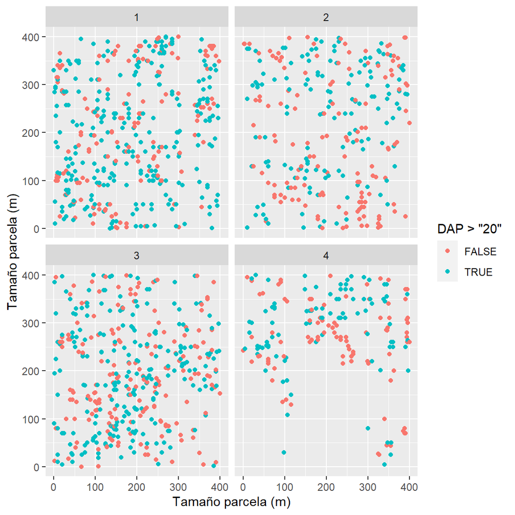

```r
# gráficos exploratorios
disp_arb <- ggplot(carapa, aes(x_rev, y)) + # asignación de base de variables "x" y "y" a partir de coordenadas x corregidas
  geom_point(aes(colour = DAP > "20" )) + # asignación de puntos y colores según adultos y subadultos
  xlab("Tamaño parcela (m)") + # título eje x
  ylab("Tamaño parcela (m)") + # título eje y
  facet_wrap(carapa$Parc) # crea gráficos por parcela
disp_arb
```

```r
adultos <- subset(carapa, DAP > 20) # subconjunto de individuos adultos
subadultos <- subset(carapa, DAP < 20) # subconjunto de individuos subadultos
```

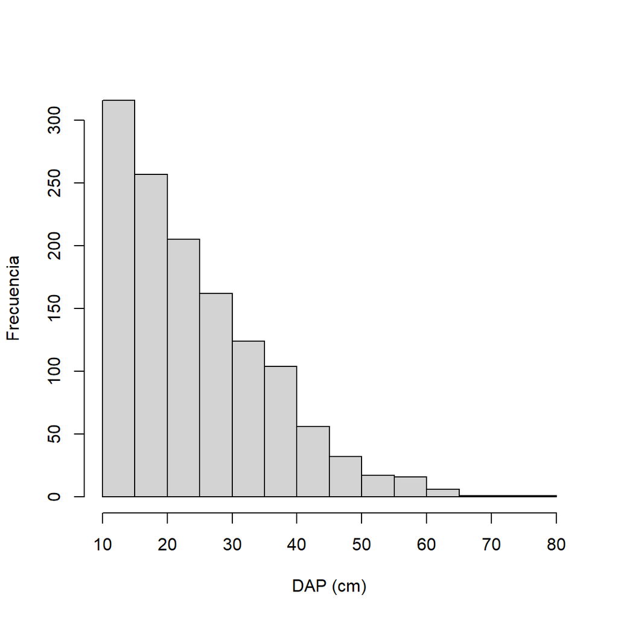

```r
hist(carapa$DAP, xlab = "DAP (cm)" , ylab = "Frecuencia", main = "") # histograma estructura según DAP para todos los datos
hist(adultos$DAP, xlab = "DAP (cm)" , ylab = "Frecuencia", main = "") # histograma estructura según DAP para adultos
hist(subadultos$DAP, xlab = "DAP (cm)" , ylab = "Frecuencia", main = "") # histograma estructura según DAP para subadultos
```

Figura 3. Histograma de frecuencias para diámetro a la altura del pecho (DAP) para individuos de *Carapa guianensis*.

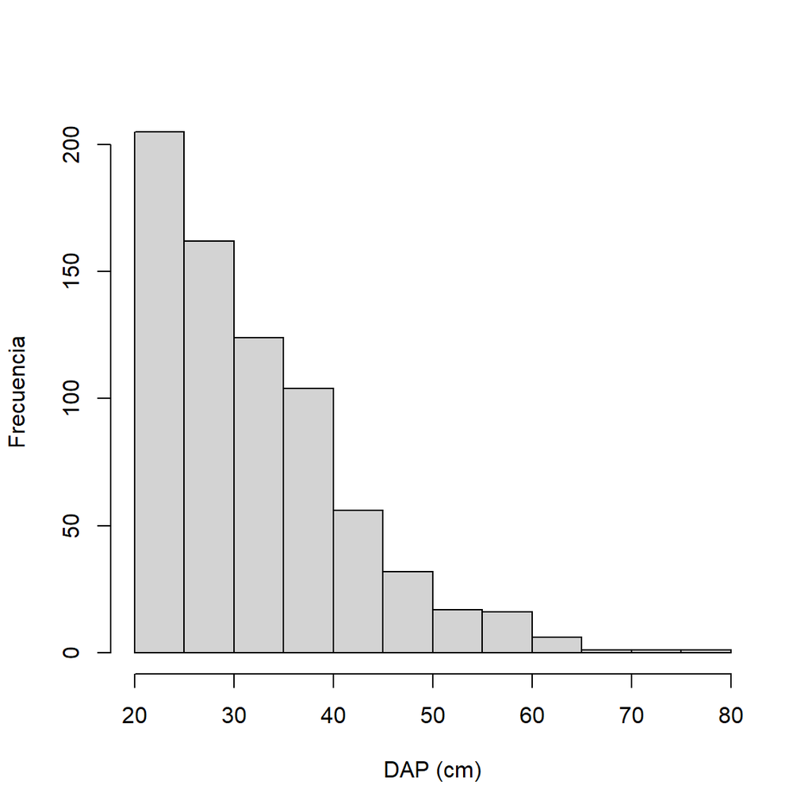

Figura 4. Histograma de frecuencias para diámetro a la altura del pecho (DAP) para individuos adultos de *Carapa guianensis*.

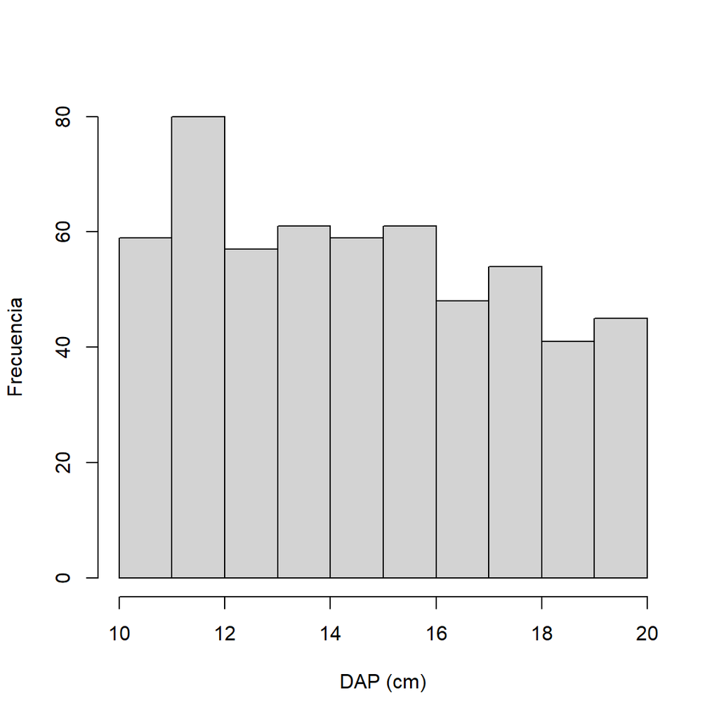

Figura 5. Histograma de frecuencias para diámetro a la altura del pecho (DAP) para individuos subadultos de *Carapa guianensis*.

Emplee el índice de patrones espaciales R para poblaciones con baja movilidad (Clark and Evans, 1954). Interpreto para valor R igual a 1 distribución aleatoria, mayor a 1 distribución uniforme y menor agregada (Fig. 6). Para estimar si las condiciones de inundado frecuentemente o no inundado afectan la distribución espacial de los individuos de *C. guianensis* calculé índice R para cada parcela según adultos y subadultos, que en todas las parcelas y estadios el indice resultante corresponde a un patrón agregado (Tabla 1).

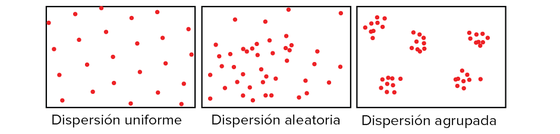

Figura 6. Patrones de agregación para organismos con movilidad reducida según indice de agregación R.

```r
# asignar formato estacial a coordenadas x y
coordpar <- function(x, y) { # x = adulto/subadulto, y = numero parcela (1:4)
  baset <- x
  subcparc <- x[x$Parc == y, ] # subconjunto adultos de parcela x
  parccoor <- ppp(subcparc$x_rev, # coordenadas en x
                  subcparc$y, # coordenadas en y
                  window = owin(c(0,400), # delimitación coordenadas x
                                c(0,400))) # delimitación coordenadas y
  return(parccoor)
}

parc1a <- coordpar(adultos, 1) # asignacion formato coordenadas para adultos por numero parcela
parc2a <- coordpar(adultos, 2)
parc3a <- coordpar(adultos, 3)
parc4a <- coordpar(adultos, 4)

parc1s <- coordpar(subadultos, 1) # asignacion formato coordenadas para subadultos por numero parcela
parc2s <- coordpar(subadultos, 2)
parc3s <- coordpar(subadultos, 3)
parc4s <- coordpar(subadultos, 4)

Ra1 <- clarkevans.test(parc1a, correction = "donnelly") # calculo de R adultos con correción efecto borde
Ra2 <- clarkevans.test(parc2a, correction = "donnelly")
Ra3 <- clarkevans.test(parc3a, correction = "donnelly")
Ra4 <- clarkevans.test(parc4a, correction = "donnelly")

Rs1 <- clarkevans.test(parc1s, correction = "donnelly") # calculo de R subadultos con correción efecto borde
Rs2 <- clarkevans.test(parc2s, correction = "donnelly")
Rs3 <- clarkevans.test(parc3s, correction = "donnelly")
Rs4 <- clarkevans.test(parc4s, correction = "donnelly")
```

Tabla 1. Patrón de agregación para individuos adultos y suadultos en parcelas de demográficas. R.index indica índice de agregación y p value estadístico de confianza respectivo.

|  | Estadio_parcela | R.index | p.value |
| --- | --- | --- | --- |
| 1 | Ra1 | 0.8683661253668032 | 0.002 |
| 2 | Ra2 | 0.8566065560900573 | 0.002 |
| 3 | Ra3 | 0.9163296664072036 | 0.018 |
| 4 | Ra4 | 0.7154386357478766 | 0.002 |
| 5 | Rs1 | 0.7114303256626555 | 0.002 |
| 6 | Rs2 | 0.843169443198304 | 0.002 |
| 7 | Rs3 | 0.9105552238428316 | 0.026 |
| 8 | Rs4 | 0.5924330764298479 | 0.002 |

```r
# estiamdo L de Besag
Lp1a <- envelope(parc1a, global=FALSE, nsim=10, transform=expression(sqrt(./pi)))
Lp2a <- envelope(parc2a, global=FALSE, nsim=10, transform=expression(sqrt(./pi)))
Lp3a <- envelope(parc3a, global=FALSE, nsim=10, transform=expression(sqrt(./pi)))
Lp4a <- envelope(parc4a, global=FALSE, nsim=10, transform=expression(sqrt(./pi)))

Lp1s <- envelope(parc1s, global=FALSE, nsim=10, transform=expression(sqrt(./pi)))
Lp2s <- envelope(parc2s, global=FALSE, nsim=10, transform=expression(sqrt(./pi)))
Lp3s <- envelope(parc3s, global=FALSE, nsim=10, transform=expression(sqrt(./pi)))
Lp4s <- envelope(parc4s, global=FALSE, nsim=10, transform=expression(sqrt(./pi)))



f2 <- function(x, y) {
  plot(x, . - theo ~ r,
     xlab= "Tamano del cuadrante (m)",
     ylab= "L de Besag",
     main= y,
     legend = FALSE) # eliminar leyenda
}
```

```r
par(mfrow = c(2, 2), oma = c(0, 0, 0, 0))

gLp1a <- f2(Lp1a, "Adultos \n Baixo (1)")
gLp1s <- f2(Lp1s, "Subadultos \n Baixo (1)")
gLp2a <- f2(Lp2a, "Terra Firme (2)")
gLp2s <- f2(Lp2s, "Terra Firme (2)")

gLp3a <- f2(Lp3a, "Baixo (3)")
gLp3s <- f2(Lp3s, "Baixo (3)")
gLp4a <- f2(Lp4a, "Terra Firme (4)")
gLp4s <- f2(Lp4s, "Terra Firme")
```

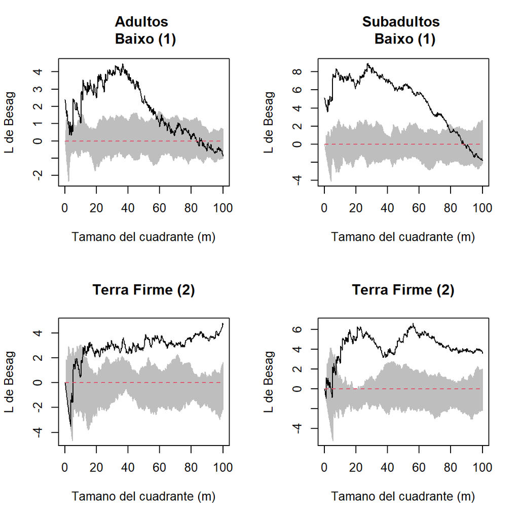

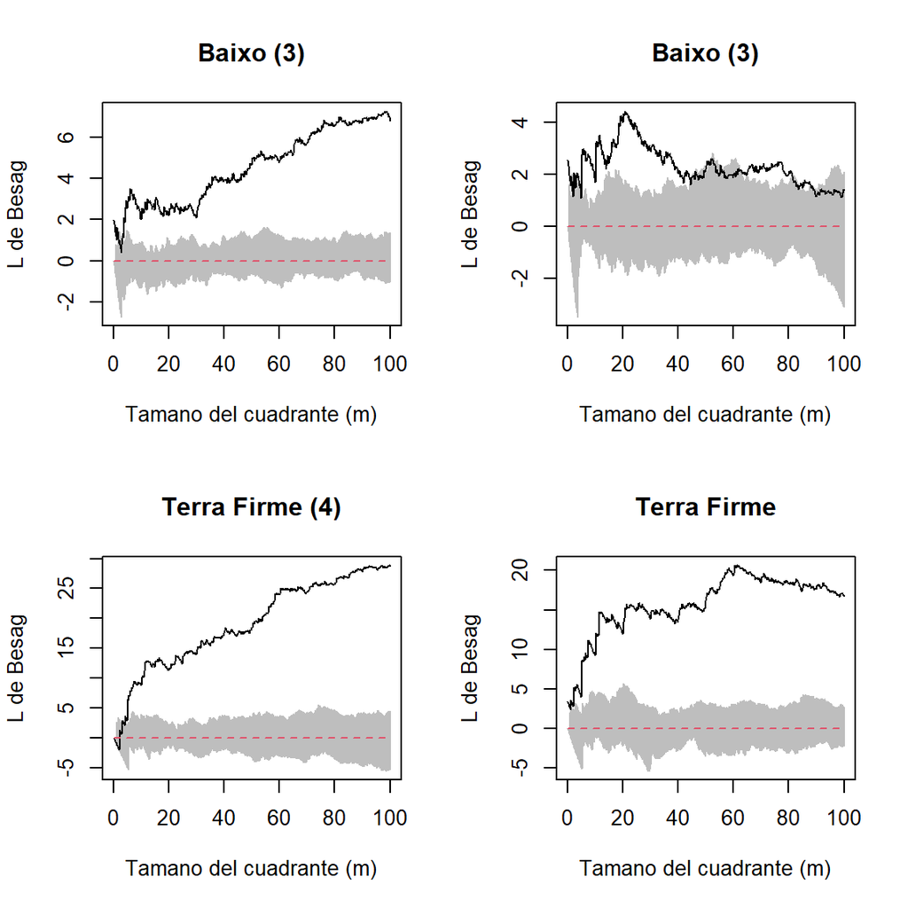

Figura 7. Patrón de agregación individual de *Carapa guanensis* según tamaño del cuadrante.

```r
carapa$DAP2 <- log(carapa$DAP)

shapiro.test(carapa$DAP2)

DAPs <- scheirerRayHare(DAP ~ Ambiente + Parc, # ScheirerRayHare test para DAP con respecto a Ambiente y parcela para totalidad de individuos
                data = carapa)

DAPsa <- scheirerRayHare(DAP ~ Ambiente + Parc, # ScheirerRayHare test para DAP adultos con respecto a Ambiente y copa
                data = adultos)

DAPss <- scheirerRayHare(DAP ~ Ambiente + Parc, # ScheirerRayHare test para DAP subadultos con respecto a Ambiente y copa
                data = subadultos)
```

[output not shown]

```r
DAPs # DAP ~ Ambiente + Parc total
```

```
##                 Df    Sum Sq       H  p.value
## Ambiente         2   1137803  8.0979 0.017440
## Parc             3    635661  4.5241 0.210150
## Ambiente:Parc    6   2045823 14.5604 0.023965
## Residuals     1286 177123084
```

```r
DAPsa # DAP ~ Ambiente + Parc adultos
```

```
##                Df   Sum Sq       H p.value
## Ambiente        2   127306  2.9025 0.23428
## Parc            3   128836  2.9374 0.40138
## Ambiente:Parc   6   494322 11.2703 0.08037
## Residuals     713 30952162
```

```r
DAPss # DAP ~ Ambiente + Parc subadultos
```

```
##                Df   Sum Sq      H p.value
## Ambiente        2    71770 2.6936 0.26007
## Parc            3   112893 4.2370 0.23698
## Ambiente:Parc   6   166905 6.2641 0.39426
## Residuals     553 14727763
```

```r
DAt <- dunnTest(DAP ~ Ambiente,
              data=carapa,
              method="bh")
DAtdif <- cldList(P.adj ~ Comparison,
        data = DAt$res,
        threshold = 0.05)
DAtdif
```

```
##        Group Letter MonoLetter
## 1     Baixio      a         a
## 2 TerraFirme      b          b
## 3  Transicao      b          b
```

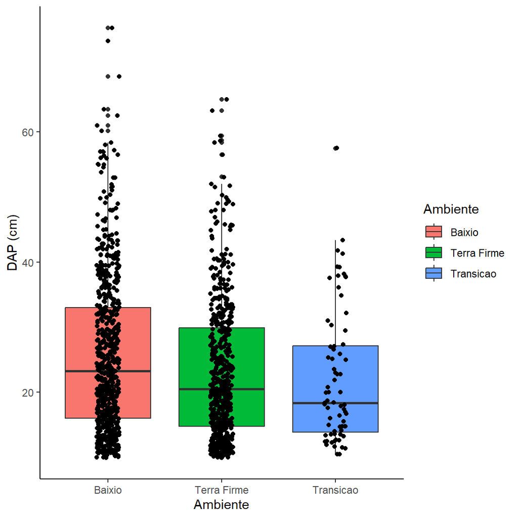

```r
boxAmb <- ggplot(carapa,aes(Ambiente, DAP)) +
  geom_boxplot(aes(fill = Ambiente)) +
  geom_jitter(width = 0.1) +
  ylab("DAP (cm)") +
  theme_classic()
boxAmb
```

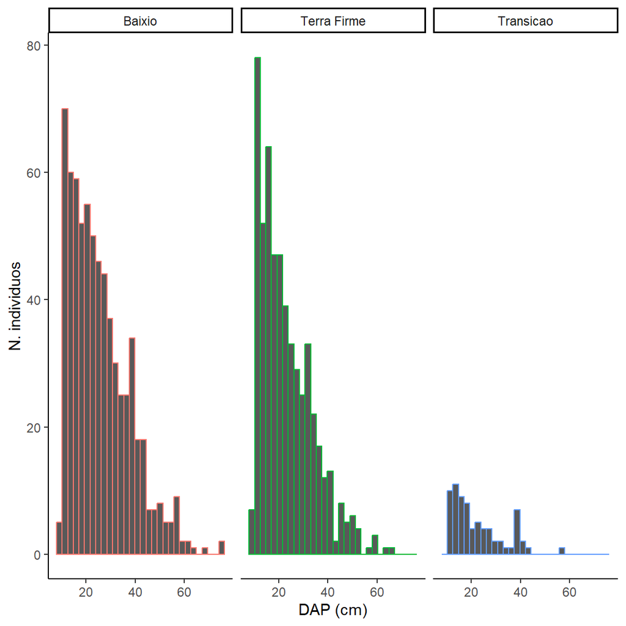

[figure not shown]

```r
contAmb <- ggplot(data = carapa, mapping = aes(x = DAP, colour = Ambiente)) +
    geom_histogram() +
    theme_bw() +
    facet_grid(. ~ Ambiente) +
    ylab("N. individuos") +
    xlab("DAP (cm)") +
    theme_classic() +
    theme(legend.position = "none")
contAmb
```

Figura 8. Medida de diámetro a la altura del pecho para diferentes ambientes en que crece *Carapa guianensis*.

[figure not shown]

Figura 9. Histograma medida de diámetro a la altura del pecho para diferentes ambientes en que crece *Carapa guianensis*.

# Discusión:

Ante este estudio recomiendo llevar a cabo un mayor esfuerzo de muestreo al aumentar la duración del censo a un minimo de cuatro años para poder contemplar influencia de periodos de masting y presencia de bancos de semillas en la zona. A su vez, sugiero explorar información de geomorfología de la región para explicar diferencia en patrones de agregación para diferentes escenarios.

## Conclusiones:

- A partir de la estructura de J invertida observada para la totalidad de la población se puede inferir reclutamiento continuo de la especie sin afectación por periodos extensos por masting o años de baja germinación y reclutamiento.
- La disponibilidad de agua en suelo en ambiente inmediato explica tendencias de tallas para Carapa guianensis de con mayor peso que si se generalizan condiciones de grandes extensiones territoriales.
- No se pueden hacer conclusiones sobre la producción de frutos debido a corto intervalo de muestreo que no contempla influencia de masting.

# Referencias

Bruna, E.M., Ribeiro, M.B.N., 2005. Regeneration and population structure of Heliconia acuminata in Amazonian secondary forests with contrasting land- use histories. *J. Trop. Ecol. 21*, 127–131

Chien, P., Zuidema, P., Nghia, N., 2008. Conservation prospects for threatened Vietnamese tree species: results from a demographic study. *Population ecology 50*, 227-237

Dayanandan, S., Dole, J., Bawa, K., Kesseli, R., 1999. Population structure delineated with microsatellite markers in fragmented populations of a tropical tree, Carapa guianensis (Meliaceae). *Mol. Ecol. 8*, 1585–1592.

Fearnside, P.M., 2005. Deforestation in Brazilian Amazonia: history, rates, and consequences. *Conserv. Biol. 19*, 680–688.

Klimas, C. 2007. Population structure of *Carapa guianensis* in two forest types in the southwestern Brazilian Amazon. *Fores Eology and Management 2007*, 256-165

Nguyen, V., Buckley, Y., Salguero-Gómez, R., Wardle, G., 2019. Consequences of neglecting cryptic life stages from demographic models. *Ecologial Modelling 408*(15)

Peres, C.A., Baider, C., Zuidema, P.A., Wadt, L.H.O., Kainer, K.A., Gomes- Silva, D.A.P., Saloma˜o, R.P., Simo˜es, L.L., Franciosi, E.R.N., Valverde, F.C., Gribel, R., Shepard, G.H., Kanashiro, M., Coventry, P., Yu, D.W., Watkinson, A.R., Freckleton, R.P., 2003. Demographic threats to the sustainability of Brazil nut exploitation. *Science 302*, 2112–2114.

Wood, C.H., 2002. *Land use and deforestation in the Amazon*. In: Wood, C.H., Porro, R. (Eds.), *Land Use and Deforestation in the Amazon*. University Press of Florida, Gainesville, FL, pp. 1–38.

# Información suplementaria

Propiedad base de datos: Christie A. Klimas, correspondiente a artículo [Population structure of Carapa guianensis in two forest types in the southwestern Brazilian Amazon](https://www.sciencedirect.com/science/article/abs/pii/S0378112707004264?via%3Dihub)

```r
DCs <- dunnTest(DAP ~ copa,
              data= carapa,
              method="bh")
DCsdif <- cldList(P.adj ~ Comparison,
        data = DCs$res,
        threshold = 0.05)
DCsdif
```

```
##           Group Letter MonoLetter
## 1   codominante      a       a
## 2     dominante      b        b
## 3 intermediaria      c         c
## 4     suprimida      d          d
```

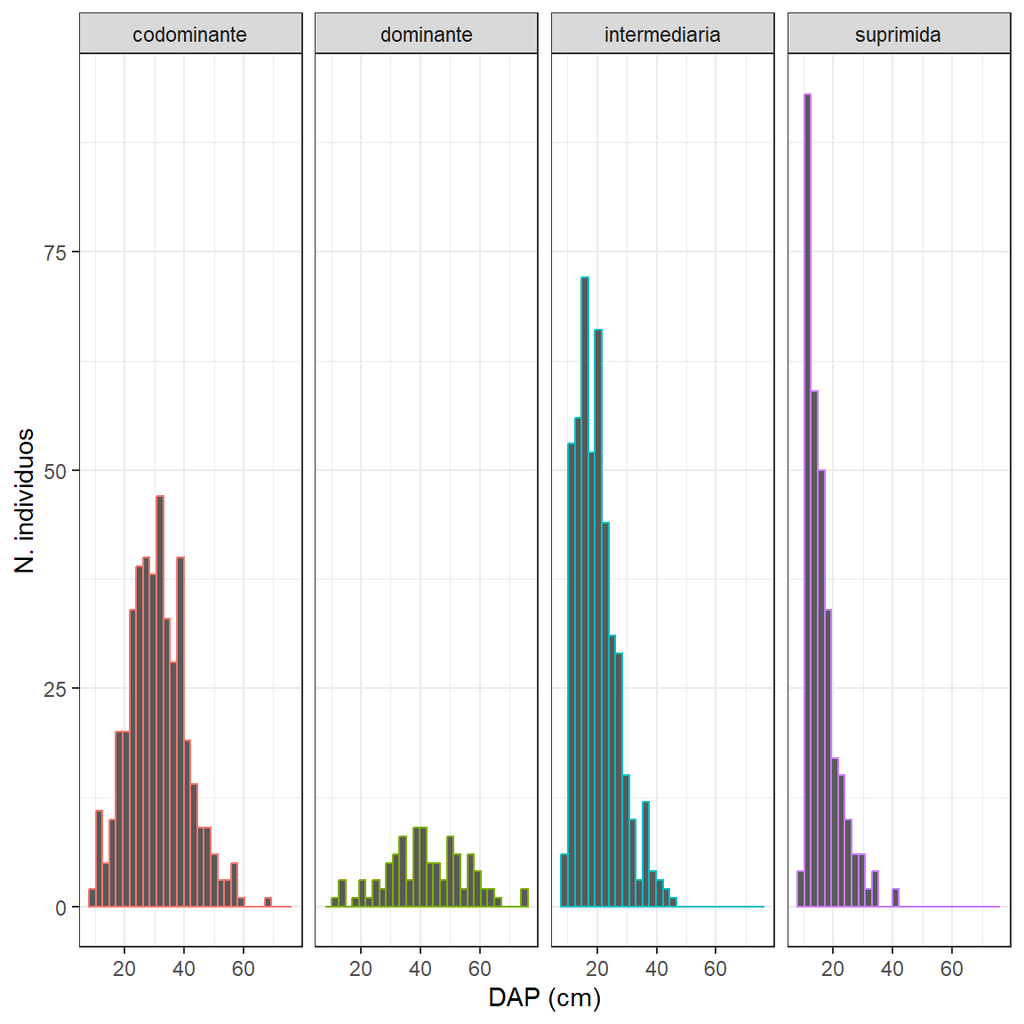

```r
contAmb <- ggplot(data = carapa, mapping = aes(x = DAP, colour = copa)) +
    geom_histogram() +
    theme_bw() +
    facet_grid(. ~ copa) +
    ylab("N. individuos") +
    xlab("DAP (cm)") +
    theme(legend.position = "none")
contAmb
```

Figura complementaria 1. Histograma para diámetro a la altura del pecho según estrado del dosel para *Carapa guianensis*

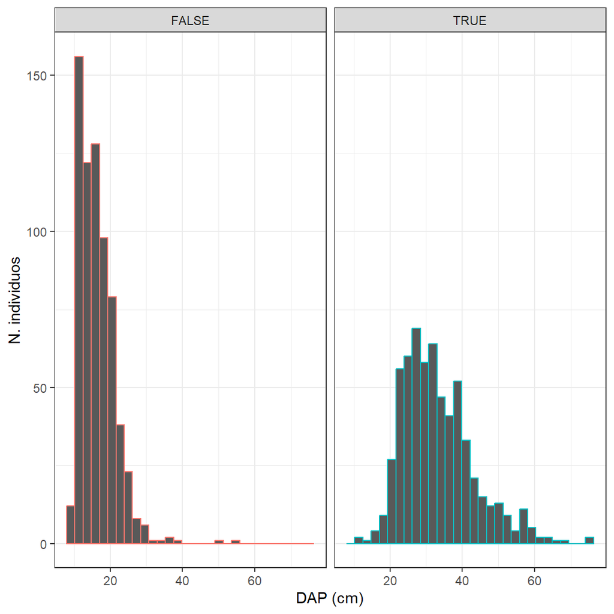

```r
contprod <- ggplot(data = carapa, mapping = aes(x = DAP, colour = Prod.)) +
    geom_histogram() +
    theme_bw() +
    facet_grid(. ~ Prod.) +
    ylab("N. individuos") +
    xlab("DAP (cm)") +
    theme(legend.position = "none")
contprod
```

Figura complementaria 2. Histograma para producción de frutos según diámetro a la altura para *Carapa guianensis*